# Risk Factor Analysis

## Outcome Variable

**Outcome Variable:** pers_wast

## Predictor Variables

**Intervention Variable:** birthlen

**Adjustment Set:**

- arm
- sex
- W_mage
- meducyrs
- feducyrs
- vagbrth
- single
- brthmon
- W_parity
- delta_W_mage
- delta_meducyrs
- delta_feducyrs
- delta_vagbrth
- delta_single
- delta_brthmon
- delta_W_parity

## Stratifying Variables

The analysis was stratified on these variable(s):

- agecat
- studyid
- country

## Data Summary

| agecat | studyid | country | birthlen | pers_wast | n_cell | n |
| --- | --- | --- | --- | --- | --- | --- |
| 0-24 months | CMC-V-BCS-2002 | INDIA | >=50 cm | 0 | 16 | 106 |
| 0-24 months | CMC-V-BCS-2002 | INDIA | >=50 cm | 1 | 0 | 106 |
| 0-24 months | CMC-V-BCS-2002 | INDIA | <48 cm | 0 | 45 | 106 |
| 0-24 months | CMC-V-BCS-2002 | INDIA | <48 cm | 1 | 5 | 106 |
| 0-24 months | CMC-V-BCS-2002 | INDIA | [48-50) cm | 0 | 39 | 106 |
| 0-24 months | CMC-V-BCS-2002 | INDIA | [48-50) cm | 1 | 1 | 106 |
| 0-24 months | CMIN | BANGLADESH | >=50 cm | 0 | 0 | 12 |
| 0-24 months | CMIN | BANGLADESH | >=50 cm | 1 | 0 | 12 |
| 0-24 months | CMIN | BANGLADESH | <48 cm | 0 | 6 | 12 |
| 0-24 months | CMIN | BANGLADESH | <48 cm | 1 | 0 | 12 |
| 0-24 months | CMIN | BANGLADESH | [48-50) cm | 0 | 6 | 12 |
| 0-24 months | CMIN | BANGLADESH | [48-50) cm | 1 | 0 | 12 |
| 0-24 months | COHORTS | GUATEMALA | >=50 cm | 0 | 340 | 699 |
| 0-24 months | COHORTS | GUATEMALA | >=50 cm | 1 | 7 | 699 |
| 0-24 months | COHORTS | GUATEMALA | <48 cm | 0 | 136 | 699 |
| 0-24 months | COHORTS | GUATEMALA | <48 cm | 1 | 5 | 699 |
| 0-24 months | COHORTS | GUATEMALA | [48-50) cm | 0 | 206 | 699 |
| 0-24 months | COHORTS | GUATEMALA | [48-50) cm | 1 | 5 | 699 |
| 0-24 months | COHORTS | INDIA | >=50 cm | 0 | 1096 | 5267 |
| 0-24 months | COHORTS | INDIA | >=50 cm | 1 | 76 | 5267 |
| 0-24 months | COHORTS | INDIA | <48 cm | 0 | 1865 | 5267 |
| 0-24 months | COHORTS | INDIA | <48 cm | 1 | 253 | 5267 |
| 0-24 months | COHORTS | INDIA | [48-50) cm | 0 | 1799 | 5267 |
| 0-24 months | COHORTS | INDIA | [48-50) cm | 1 | 178 | 5267 |
| 0-24 months | COHORTS | PHILIPPINES | >=50 cm | 0 | 998 | 2804 |
| 0-24 months | COHORTS | PHILIPPINES | >=50 cm | 1 | 39 | 2804 |
| 0-24 months | COHORTS | PHILIPPINES | <48 cm | 0 | 653 | 2804 |
| 0-24 months | COHORTS | PHILIPPINES | <48 cm | 1 | 48 | 2804 |
| 0-24 months | COHORTS | PHILIPPINES | [48-50) cm | 0 | 1010 | 2804 |
| 0-24 months | COHORTS | PHILIPPINES | [48-50) cm | 1 | 56 | 2804 |

[output cut: 414 more lines]

The following strata were considered:

- agecat: 0-24 months, studyid: CMC-V-BCS-2002, country: INDIA
- agecat: 0-24 months, studyid: CMIN, country: BANGLADESH
- agecat: 0-24 months, studyid: COHORTS, country: GUATEMALA
- agecat: 0-24 months, studyid: COHORTS, country: INDIA
- agecat: 0-24 months, studyid: COHORTS, country: PHILIPPINES
- agecat: 0-24 months, studyid: CONTENT, country: PERU
- agecat: 0-24 months, studyid: EE, country: PAKISTAN
- agecat: 0-24 months, studyid: GMS-Nepal, country: NEPAL
- agecat: 0-24 months, studyid: IRC, country: INDIA
- agecat: 0-24 months, studyid: JiVitA-3, country: BANGLADESH
- agecat: 0-24 months, studyid: JiVitA-4, country: BANGLADESH
- agecat: 0-24 months, studyid: Keneba, country: GAMBIA
- agecat: 0-24 months, studyid: MAL-ED, country: BANGLADESH
- agecat: 0-24 months, studyid: MAL-ED, country: BRAZIL
- agecat: 0-24 months, studyid: MAL-ED, country: INDIA
- agecat: 0-24 months, studyid: MAL-ED, country: NEPAL
- agecat: 0-24 months, studyid: MAL-ED, country: PERU
- agecat: 0-24 months, studyid: MAL-ED, country: SOUTH AFRICA
- agecat: 0-24 months, studyid: MAL-ED, country: TANZANIA, UNITED REPUBLIC OF
- agecat: 0-24 months, studyid: NIH-Birth, country: BANGLADESH
- agecat: 0-24 months, studyid: NIH-Crypto, country: BANGLADESH
- agecat: 0-24 months, studyid: PROBIT, country: BELARUS
- agecat: 0-24 months, studyid: PROVIDE, country: BANGLADESH
- agecat: 0-24 months, studyid: ResPak, country: PAKISTAN
- agecat: 0-24 months, studyid: SAS-CompFeed, country: INDIA
- agecat: 0-24 months, studyid: ZVITAMBO, country: ZIMBABWE
- agecat: 0-6 months, studyid: CMC-V-BCS-2002, country: INDIA
- agecat: 0-6 months, studyid: CMIN, country: BANGLADESH
- agecat: 0-6 months, studyid: COHORTS, country: PHILIPPINES
- agecat: 0-6 months, studyid: CONTENT, country: PERU
- agecat: 0-6 months, studyid: EE, country: PAKISTAN
- agecat: 0-6 months, studyid: GMS-Nepal, country: NEPAL
- agecat: 0-6 months, studyid: IRC, country: INDIA
- agecat: 0-6 months, studyid: JiVitA-3, country: BANGLADESH
- agecat: 0-6 months, studyid: Keneba, country: GAMBIA
- agecat: 0-6 months, studyid: MAL-ED, country: BANGLADESH
- agecat: 0-6 months, studyid: MAL-ED, country: BRAZIL
- agecat: 0-6 months, studyid: MAL-ED, country: INDIA
- agecat: 0-6 months, studyid: MAL-ED, country: NEPAL
- agecat: 0-6 months, studyid: MAL-ED, country: PERU
- agecat: 0-6 months, studyid: MAL-ED, country: SOUTH AFRICA
- agecat: 0-6 months, studyid: MAL-ED, country: TANZANIA, UNITED REPUBLIC OF
- agecat: 0-6 months, studyid: NIH-Birth, country: BANGLADESH
- agecat: 0-6 months, studyid: NIH-Crypto, country: BANGLADESH
- agecat: 0-6 months, studyid: PROBIT, country: BELARUS
- agecat: 0-6 months, studyid: PROVIDE, country: BANGLADESH
- agecat: 0-6 months, studyid: ResPak, country: PAKISTAN
- agecat: 0-6 months, studyid: ZVITAMBO, country: ZIMBABWE
- agecat: 6-24 months, studyid: CMC-V-BCS-2002, country: INDIA
- agecat: 6-24 months, studyid: CMIN, country: BANGLADESH
- agecat: 6-24 months, studyid: COHORTS, country: GUATEMALA
- agecat: 6-24 months, studyid: COHORTS, country: INDIA
- agecat: 6-24 months, studyid: COHORTS, country: PHILIPPINES
- agecat: 6-24 months, studyid: CONTENT, country: PERU
- agecat: 6-24 months, studyid: EE, country: PAKISTAN
- agecat: 6-24 months, studyid: GMS-Nepal, country: NEPAL
- agecat: 6-24 months, studyid: IRC, country: INDIA
- agecat: 6-24 months, studyid: JiVitA-3, country: BANGLADESH
- agecat: 6-24 months, studyid: JiVitA-4, country: BANGLADESH
- agecat: 6-24 months, studyid: Keneba, country: GAMBIA
- agecat: 6-24 months, studyid: MAL-ED, country: BANGLADESH
- agecat: 6-24 months, studyid: MAL-ED, country: BRAZIL
- agecat: 6-24 months, studyid: MAL-ED, country: INDIA
- agecat: 6-24 months, studyid: MAL-ED, country: NEPAL
- agecat: 6-24 months, studyid: MAL-ED, country: PERU
- agecat: 6-24 months, studyid: MAL-ED, country: SOUTH AFRICA
- agecat: 6-24 months, studyid: MAL-ED, country: TANZANIA, UNITED REPUBLIC OF
- agecat: 6-24 months, studyid: NIH-Birth, country: BANGLADESH
- agecat: 6-24 months, studyid: NIH-Crypto, country: BANGLADESH
- agecat: 6-24 months, studyid: PROBIT, country: BELARUS
- agecat: 6-24 months, studyid: PROVIDE, country: BANGLADESH
- agecat: 6-24 months, studyid: ResPak, country: PAKISTAN
- agecat: 6-24 months, studyid: SAS-CompFeed, country: INDIA
- agecat: 6-24 months, studyid: ZVITAMBO, country: ZIMBABWE

### Dropped Strata

Some strata were dropped due to rare outcomes:

- agecat: 0-24 months, studyid: CMC-V-BCS-2002, country: INDIA
- agecat: 0-24 months, studyid: CMIN, country: BANGLADESH
- agecat: 0-24 months, studyid: CONTENT, country: PERU
- agecat: 0-24 months, studyid: EE, country: PAKISTAN
- agecat: 0-24 months, studyid: MAL-ED, country: BANGLADESH
- agecat: 0-24 months, studyid: MAL-ED, country: BRAZIL
- agecat: 0-24 months, studyid: MAL-ED, country: INDIA
- agecat: 0-24 months, studyid: MAL-ED, country: NEPAL
- agecat: 0-24 months, studyid: MAL-ED, country: PERU
- agecat: 0-24 months, studyid: MAL-ED, country: SOUTH AFRICA
- agecat: 0-24 months, studyid: MAL-ED, country: TANZANIA, UNITED REPUBLIC OF
- agecat: 0-24 months, studyid: NIH-Crypto, country: BANGLADESH
- agecat: 0-24 months, studyid: PROBIT, country: BELARUS
- agecat: 0-24 months, studyid: PROVIDE, country: BANGLADESH
- agecat: 0-24 months, studyid: ResPak, country: PAKISTAN
- agecat: 0-6 months, studyid: CMC-V-BCS-2002, country: INDIA
- agecat: 0-6 months, studyid: CMIN, country: BANGLADESH
- agecat: 0-6 months, studyid: CONTENT, country: PERU
- agecat: 0-6 months, studyid: EE, country: PAKISTAN
- agecat: 0-6 months, studyid: JiVitA-3, country: BANGLADESH
- agecat: 0-6 months, studyid: MAL-ED, country: BANGLADESH
- agecat: 0-6 months, studyid: MAL-ED, country: BRAZIL
- agecat: 0-6 months, studyid: MAL-ED, country: INDIA
- agecat: 0-6 months, studyid: MAL-ED, country: NEPAL
- agecat: 0-6 months, studyid: MAL-ED, country: PERU
- agecat: 0-6 months, studyid: MAL-ED, country: SOUTH AFRICA
- agecat: 0-6 months, studyid: MAL-ED, country: TANZANIA, UNITED REPUBLIC OF
- agecat: 0-6 months, studyid: NIH-Birth, country: BANGLADESH
- agecat: 0-6 months, studyid: NIH-Crypto, country: BANGLADESH
- agecat: 0-6 months, studyid: PROBIT, country: BELARUS
- agecat: 0-6 months, studyid: PROVIDE, country: BANGLADESH
- agecat: 0-6 months, studyid: ResPak, country: PAKISTAN
- agecat: 0-6 months, studyid: ZVITAMBO, country: ZIMBABWE
- agecat: 6-24 months, studyid: CMC-V-BCS-2002, country: INDIA
- agecat: 6-24 months, studyid: CMIN, country: BANGLADESH
- agecat: 6-24 months, studyid: CONTENT, country: PERU
- agecat: 6-24 months, studyid: EE, country: PAKISTAN
- agecat: 6-24 months, studyid: MAL-ED, country: BANGLADESH
- agecat: 6-24 months, studyid: MAL-ED, country: BRAZIL
- agecat: 6-24 months, studyid: MAL-ED, country: INDIA
- agecat: 6-24 months, studyid: MAL-ED, country: NEPAL
- agecat: 6-24 months, studyid: MAL-ED, country: PERU
- agecat: 6-24 months, studyid: MAL-ED, country: SOUTH AFRICA
- agecat: 6-24 months, studyid: MAL-ED, country: TANZANIA, UNITED REPUBLIC OF
- agecat: 6-24 months, studyid: NIH-Crypto, country: BANGLADESH
- agecat: 6-24 months, studyid: PROBIT, country: BELARUS
- agecat: 6-24 months, studyid: PROVIDE, country: BANGLADESH
- agecat: 6-24 months, studyid: ResPak, country: PAKISTAN

## Methods Detail

We’re interested in the causal parameters $E[Y_a]$ for all values of $a \in \mathcal{A}$. These parameters represent the mean outcome if, possibly contrary to fact, we intervened to set all units to have $A=a$. Under the randomization and positivity assumptions, these are identified by the statistical parameters $\psi_a=E_W[E_{Y|A,W}(Y|A=a,W)]$. In addition, we’re interested in the mean of $Y$, $E[Y]$ under no intervention (the observed mean). We will estimate these parameters by using SuperLearner to fit the relevant likelihood factors – $E_{Y|A,W}(Y|A=a,W)$ and $p(A=a|W)$, and then updating our likelihood fit using a joint TMLE.

For unadjusted analyses ($W=\{\}$), initial likelihoods were estimated using Lrnr_glm to estimate the simple $E(Y|A)$ and Lrnr_mean to estimate $p(A)$. For adjusted analyses, a small library containing Lrnr_glmnet, Lrnr_xgboost, and Lrnr_mean was used.

Having estimated these parameters, we will then use the delta method to estimate relative risks and attributable risks relative to a prespecified baseline level of $A$.

# Results Detail

## Results Plots

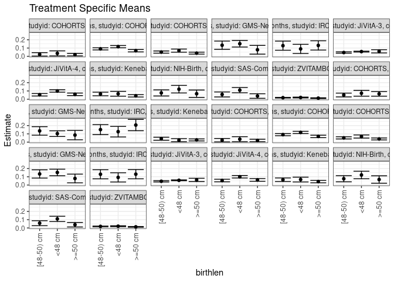

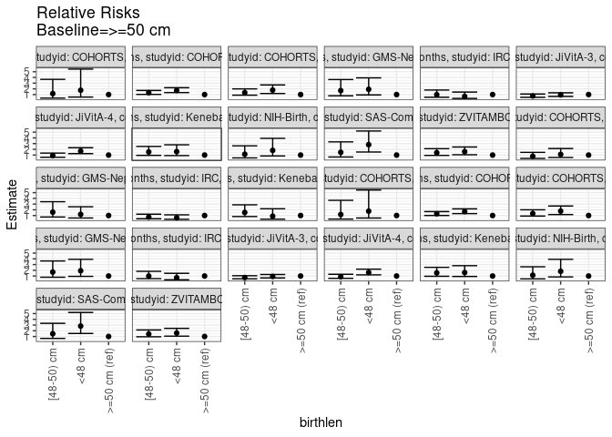

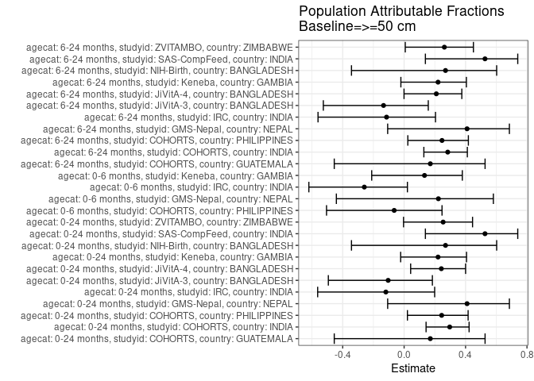

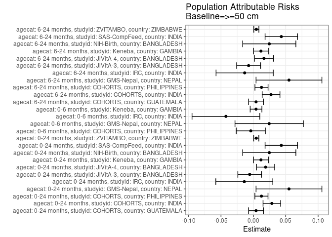

## Results Table

### Parameter: TSM

| agecat | studyid | country | intervention_level | baseline_level | estimate | ci_lower | ci_upper |
| --- | --- | --- | --- | --- | --- | --- | --- |
| 0-24 months | COHORTS | GUATEMALA | >=50 cm | NA | 0.0201729 | 0.0053698 | 0.0349760 |
| 0-24 months | COHORTS | GUATEMALA | <48 cm | NA | 0.0354610 | 0.0049129 | 0.0660091 |
| 0-24 months | COHORTS | GUATEMALA | [48-50) cm | NA | 0.0236967 | 0.0031589 | 0.0442345 |
| 0-24 months | COHORTS | INDIA | >=50 cm | NA | 0.0676854 | 0.0531422 | 0.0822286 |
| 0-24 months | COHORTS | INDIA | <48 cm | NA | 0.1166799 | 0.1029484 | 0.1304113 |
| 0-24 months | COHORTS | INDIA | [48-50) cm | NA | 0.0901343 | 0.0773385 | 0.1029300 |
| 0-24 months | COHORTS | PHILIPPINES | >=50 cm | NA | 0.0385300 | 0.0268181 | 0.0502418 |
| 0-24 months | COHORTS | PHILIPPINES | <48 cm | NA | 0.0687496 | 0.0498435 | 0.0876558 |
| 0-24 months | COHORTS | PHILIPPINES | [48-50) cm | NA | 0.0514936 | 0.0381446 | 0.0648426 |
| 0-24 months | GMS-Nepal | NEPAL | >=50 cm | NA | 0.0792079 | 0.0264950 | 0.1319208 |
| 0-24 months | GMS-Nepal | NEPAL | <48 cm | NA | 0.1518987 | 0.1122919 | 0.1915056 |
| 0-24 months | GMS-Nepal | NEPAL | [48-50) cm | NA | 0.1340782 | 0.0841203 | 0.1840362 |
| 0-24 months | IRC | INDIA | >=50 cm | NA | 0.1316486 | 0.0757998 | 0.1874973 |
| 0-24 months | IRC | INDIA | <48 cm | NA | 0.0895371 | 0.0343010 | 0.1447731 |
| 0-24 months | IRC | INDIA | [48-50) cm | NA | 0.1286787 | 0.0734500 | 0.1839074 |
| 0-24 months | JiVitA-3 | BANGLADESH | >=50 cm | NA | 0.0603739 | 0.0409316 | 0.0798162 |
| 0-24 months | JiVitA-3 | BANGLADESH | <48 cm | NA | 0.0570229 | 0.0518833 | 0.0621625 |
| 0-24 months | JiVitA-3 | BANGLADESH | [48-50) cm | NA | 0.0458038 | 0.0375414 | 0.0540661 |
| 0-24 months | JiVitA-4 | BANGLADESH | >=50 cm | NA | 0.0591093 | 0.0437268 | 0.0744918 |
| 0-24 months | JiVitA-4 | BANGLADESH | <48 cm | NA | 0.0998492 | 0.0850082 | 0.1146901 |
| 0-24 months | JiVitA-4 | BANGLADESH | [48-50) cm | NA | 0.0539214 | 0.0388783 | 0.0689646 |
| 0-24 months | Keneba | GAMBIA | >=50 cm | NA | 0.0413034 | 0.0268900 | 0.0557169 |
| 0-24 months | Keneba | GAMBIA | <48 cm | NA | 0.0657843 | 0.0368221 | 0.0947466 |
| 0-24 months | Keneba | GAMBIA | [48-50) cm | NA | 0.0634924 | 0.0417240 | 0.0852609 |
| 0-24 months | NIH-Birth | BANGLADESH | >=50 cm | NA | 0.0666667 | 0.0219929 | 0.1113404 |
| 0-24 months | NIH-Birth | BANGLADESH | <48 cm | NA | 0.1212121 | 0.0757078 | 0.1667164 |
| 0-24 months | NIH-Birth | BANGLADESH | [48-50) cm | NA | 0.0761421 | 0.0390696 | 0.1132147 |
| 0-24 months | SAS-CompFeed | INDIA | >=50 cm | NA | 0.0388350 | 0.0114714 | 0.0661985 |
| 0-24 months | SAS-CompFeed | INDIA | <48 cm | NA | 0.1095506 | 0.0778598 | 0.1412413 |
| 0-24 months | SAS-CompFeed | INDIA | [48-50) cm | NA | 0.0574713 | 0.0276190 | 0.0873235 |
| 0-24 months | ZVITAMBO | ZIMBABWE | >=50 cm | NA | 0.0131267 | 0.0087611 | 0.0174922 |
| 0-24 months | ZVITAMBO | ZIMBABWE | <48 cm | NA | 0.0209023 | 0.0157590 | 0.0260456 |
| 0-24 months | ZVITAMBO | ZIMBABWE | [48-50) cm | NA | 0.0184524 | 0.0140887 | 0.0228161 |
| 0-6 months | COHORTS | PHILIPPINES | >=50 cm | NA | 0.0649098 | 0.0367540 | 0.0930656 |
| 0-6 months | COHORTS | PHILIPPINES | <48 cm | NA | 0.0723250 | 0.0370322 | 0.1076179 |
| 0-6 months | COHORTS | PHILIPPINES | [48-50) cm | NA | 0.0509953 | 0.0281243 | 0.0738663 |
| 0-6 months | GMS-Nepal | NEPAL | >=50 cm | NA | 0.0851064 | 0.0286472 | 0.1415656 |
| 0-6 months | GMS-Nepal | NEPAL | <48 cm | NA | 0.1026490 | 0.0683890 | 0.1369090 |
| 0-6 months | GMS-Nepal | NEPAL | [48-50) cm | NA | 0.1352941 | 0.0838328 | 0.1867555 |
| 0-6 months | IRC | INDIA | >=50 cm | NA | 0.2060584 | 0.1380337 | 0.2740831 |
| 0-6 months | IRC | INDIA | <48 cm | NA | 0.1262801 | 0.0626201 | 0.1899401 |
| 0-6 months | IRC | INDIA | [48-50) cm | NA | 0.1511794 | 0.0907395 | 0.2116193 |
| 0-6 months | Keneba | GAMBIA | >=50 cm | NA | 0.0269122 | 0.0149709 | 0.0388534 |
| 0-6 months | Keneba | GAMBIA | <48 cm | NA | 0.0237154 | 0.0049592 | 0.0424716 |
| 0-6 months | Keneba | GAMBIA | [48-50) cm | NA | 0.0413943 | 0.0231644 | 0.0596243 |
| 6-24 months | COHORTS | GUATEMALA | >=50 cm | NA | 0.0201729 | 0.0053698 | 0.0349760 |
| 6-24 months | COHORTS | GUATEMALA | <48 cm | NA | 0.0354610 | 0.0049129 | 0.0660091 |
| 6-24 months | COHORTS | GUATEMALA | [48-50) cm | NA | 0.0236967 | 0.0031589 | 0.0442345 |
| 6-24 months | COHORTS | INDIA | >=50 cm | NA | 0.0689294 | 0.0542216 | 0.0836372 |
| 6-24 months | COHORTS | INDIA | <48 cm | NA | 0.1170616 | 0.1033018 | 0.1308215 |
| 6-24 months | COHORTS | INDIA | [48-50) cm | NA | 0.0901843 | 0.0773059 | 0.1030626 |
| 6-24 months | COHORTS | PHILIPPINES | >=50 cm | NA | 0.0384230 | 0.0267379 | 0.0501081 |
| 6-24 months | COHORTS | PHILIPPINES | <48 cm | NA | 0.0679150 | 0.0491321 | 0.0866978 |
| 6-24 months | COHORTS | PHILIPPINES | [48-50) cm | NA | 0.0517016 | 0.0383280 | 0.0650753 |
| 6-24 months | GMS-Nepal | NEPAL | >=50 cm | NA | 0.0792079 | 0.0264950 | 0.1319208 |
| 6-24 months | GMS-Nepal | NEPAL | <48 cm | NA | 0.1518987 | 0.1122919 | 0.1915056 |
| 6-24 months | GMS-Nepal | NEPAL | [48-50) cm | NA | 0.1340782 | 0.0841203 | 0.1840362 |
| 6-24 months | IRC | INDIA | >=50 cm | NA | 0.1311063 | 0.0752625 | 0.1869501 |
| 6-24 months | IRC | INDIA | <48 cm | NA | 0.0924238 | 0.0367760 | 0.1480716 |
| 6-24 months | IRC | INDIA | [48-50) cm | NA | 0.1301122 | 0.0749398 | 0.1852845 |
| 6-24 months | JiVitA-3 | BANGLADESH | >=50 cm | NA | 0.0620236 | 0.0423722 | 0.0816749 |
| 6-24 months | JiVitA-3 | BANGLADESH | <48 cm | NA | 0.0570449 | 0.0518835 | 0.0622063 |
| 6-24 months | JiVitA-3 | BANGLADESH | [48-50) cm | NA | 0.0453889 | 0.0373278 | 0.0534501 |
| 6-24 months | JiVitA-4 | BANGLADESH | >=50 cm | NA | 0.0616541 | 0.0454528 | 0.0778553 |
| 6-24 months | JiVitA-4 | BANGLADESH | <48 cm | NA | 0.1001442 | 0.0852157 | 0.1150726 |
| 6-24 months | JiVitA-4 | BANGLADESH | [48-50) cm | NA | 0.0543308 | 0.0388264 | 0.0698352 |
| 6-24 months | Keneba | GAMBIA | >=50 cm | NA | 0.0413096 | 0.0269720 | 0.0556472 |
| 6-24 months | Keneba | GAMBIA | <48 cm | NA | 0.0663157 | 0.0374208 | 0.0952106 |
| 6-24 months | Keneba | GAMBIA | [48-50) cm | NA | 0.0639242 | 0.0421921 | 0.0856563 |
| 6-24 months | NIH-Birth | BANGLADESH | >=50 cm | NA | 0.0666667 | 0.0219929 | 0.1113404 |
| 6-24 months | NIH-Birth | BANGLADESH | <48 cm | NA | 0.1212121 | 0.0757078 | 0.1667164 |
| 6-24 months | NIH-Birth | BANGLADESH | [48-50) cm | NA | 0.0761421 | 0.0390696 | 0.1132147 |
| 6-24 months | SAS-CompFeed | INDIA | >=50 cm | NA | 0.0388350 | 0.0114714 | 0.0661985 |
| 6-24 months | SAS-CompFeed | INDIA | <48 cm | NA | 0.1095506 | 0.0778598 | 0.1412413 |
| 6-24 months | SAS-CompFeed | INDIA | [48-50) cm | NA | 0.0574713 | 0.0276190 | 0.0873235 |
| 6-24 months | ZVITAMBO | ZIMBABWE | >=50 cm | NA | 0.0129858 | 0.0086722 | 0.0172995 |
| 6-24 months | ZVITAMBO | ZIMBABWE | <48 cm | NA | 0.0207851 | 0.0156490 | 0.0259213 |
| 6-24 months | ZVITAMBO | ZIMBABWE | [48-50) cm | NA | 0.0185389 | 0.0141733 | 0.0229046 |

### Parameter: E(Y)

| agecat | studyid | country | intervention_level | baseline_level | estimate | ci_lower | ci_upper |
| --- | --- | --- | --- | --- | --- | --- | --- |
| 0-24 months | COHORTS | GUATEMALA | NA | NA | 0.0243205 | 0.0128927 | 0.0357482 |
| 0-24 months | COHORTS | INDIA | NA | NA | 0.0962597 | 0.0882935 | 0.1042259 |
| 0-24 months | COHORTS | PHILIPPINES | NA | NA | 0.0509986 | 0.0428544 | 0.0591428 |
| 0-24 months | GMS-Nepal | NEPAL | NA | NA | 0.1342282 | 0.1068369 | 0.1616195 |
| 0-24 months | IRC | INDIA | NA | NA | 0.1176471 | 0.0856708 | 0.1496233 |
| 0-24 months | JiVitA-3 | BANGLADESH | NA | NA | 0.0546893 | 0.0503788 | 0.0589997 |
| 0-24 months | JiVitA-4 | BANGLADESH | NA | NA | 0.0780045 | 0.0689447 | 0.0870643 |
| 0-24 months | Keneba | GAMBIA | NA | NA | 0.0530152 | 0.0417064 | 0.0643241 |
| 0-24 months | NIH-Birth | BANGLADESH | NA | NA | 0.0912621 | 0.0663660 | 0.1161582 |
| 0-24 months | SAS-CompFeed | INDIA | NA | NA | 0.0820399 | 0.0573937 | 0.1066861 |
| 0-24 months | ZVITAMBO | ZIMBABWE | NA | NA | 0.0175959 | 0.0149427 | 0.0202492 |
| 0-6 months | COHORTS | PHILIPPINES | NA | NA | 0.0609613 | 0.0448957 | 0.0770269 |
| 0-6 months | GMS-Nepal | NEPAL | NA | NA | 0.1095406 | 0.0837882 | 0.1352931 |
| 0-6 months | IRC | INDIA | NA | NA | 0.1636364 | 0.1266348 | 0.2006379 |
| 0-6 months | Keneba | GAMBIA | NA | NA | 0.0310296 | 0.0220013 | 0.0400579 |
| 6-24 months | COHORTS | GUATEMALA | NA | NA | 0.0243205 | 0.0128927 | 0.0357482 |
| 6-24 months | COHORTS | INDIA | NA | NA | 0.0962597 | 0.0882935 | 0.1042259 |
| 6-24 months | COHORTS | PHILIPPINES | NA | NA | 0.0509986 | 0.0428544 | 0.0591428 |
| 6-24 months | GMS-Nepal | NEPAL | NA | NA | 0.1342282 | 0.1068369 | 0.1616195 |
| 6-24 months | IRC | INDIA | NA | NA | 0.1176471 | 0.0856708 | 0.1496233 |
| 6-24 months | JiVitA-3 | BANGLADESH | NA | NA | 0.0546893 | 0.0503788 | 0.0589997 |
| 6-24 months | JiVitA-4 | BANGLADESH | NA | NA | 0.0780045 | 0.0689447 | 0.0870643 |
| 6-24 months | Keneba | GAMBIA | NA | NA | 0.0530152 | 0.0417064 | 0.0643241 |
| 6-24 months | NIH-Birth | BANGLADESH | NA | NA | 0.0912621 | 0.0663660 | 0.1161582 |
| 6-24 months | SAS-CompFeed | INDIA | NA | NA | 0.0820399 | 0.0573937 | 0.1066861 |
| 6-24 months | ZVITAMBO | ZIMBABWE | NA | NA | 0.0175959 | 0.0149427 | 0.0202492 |

### Parameter: RR

| agecat | studyid | country | intervention_level | baseline_level | estimate | ci_lower | ci_upper |
| --- | --- | --- | --- | --- | --- | --- | --- |
| 0-24 months | COHORTS | GUATEMALA | >=50 cm | >=50 cm | 1.0000000 | 1.0000000 | 1.000000 |
| 0-24 months | COHORTS | GUATEMALA | <48 cm | >=50 cm | 1.7578521 | 0.5669193 | 5.450589 |
| 0-24 months | COHORTS | GUATEMALA | [48-50) cm | >=50 cm | 1.1746784 | 0.3773324 | 3.656907 |
| 0-24 months | COHORTS | INDIA | >=50 cm | >=50 cm | 1.0000000 | 1.0000000 | 1.000000 |
| 0-24 months | COHORTS | INDIA | <48 cm | >=50 cm | 1.7238563 | 1.3496924 | 2.201747 |
| 0-24 months | COHORTS | INDIA | [48-50) cm | >=50 cm | 1.3316650 | 1.0296942 | 1.722192 |
| 0-24 months | COHORTS | PHILIPPINES | >=50 cm | >=50 cm | 1.0000000 | 1.0000000 | 1.000000 |
| 0-24 months | COHORTS | PHILIPPINES | <48 cm | >=50 cm | 1.7843157 | 1.1845760 | 2.687698 |
| 0-24 months | COHORTS | PHILIPPINES | [48-50) cm | >=50 cm | 1.3364562 | 0.8965108 | 1.992296 |
| 0-24 months | GMS-Nepal | NEPAL | >=50 cm | >=50 cm | 1.0000000 | 1.0000000 | 1.000000 |
| 0-24 months | GMS-Nepal | NEPAL | <48 cm | >=50 cm | 1.9177215 | 0.9383612 | 3.919233 |
| 0-24 months | GMS-Nepal | NEPAL | [48-50) cm | >=50 cm | 1.6927374 | 0.7894952 | 3.629357 |
| 0-24 months | IRC | INDIA | >=50 cm | >=50 cm | 1.0000000 | 1.0000000 | 1.000000 |
| 0-24 months | IRC | INDIA | <48 cm | >=50 cm | 0.6801218 | 0.3220900 | 1.436138 |
| 0-24 months | IRC | INDIA | [48-50) cm | >=50 cm | 0.9774409 | 0.5328596 | 1.792950 |
| 0-24 months | JiVitA-3 | BANGLADESH | >=50 cm | >=50 cm | 1.0000000 | 1.0000000 | 1.000000 |
| 0-24 months | JiVitA-3 | BANGLADESH | <48 cm | >=50 cm | 0.9444957 | 0.6818543 | 1.308303 |
| 0-24 months | JiVitA-3 | BANGLADESH | [48-50) cm | >=50 cm | 0.7586687 | 0.5241482 | 1.098121 |
| 0-24 months | JiVitA-4 | BANGLADESH | >=50 cm | >=50 cm | 1.0000000 | 1.0000000 | 1.000000 |
| 0-24 months | JiVitA-4 | BANGLADESH | <48 cm | >=50 cm | 1.6892299 | 1.2507074 | 2.281507 |
| 0-24 months | JiVitA-4 | BANGLADESH | [48-50) cm | >=50 cm | 0.9122326 | 0.6195735 | 1.343131 |
| 0-24 months | Keneba | GAMBIA | >=50 cm | >=50 cm | 1.0000000 | 1.0000000 | 1.000000 |
| 0-24 months | Keneba | GAMBIA | <48 cm | >=50 cm | 1.5927086 | 0.9084771 | 2.792278 |
| 0-24 months | Keneba | GAMBIA | [48-50) cm | >=50 cm | 1.5372188 | 0.9426044 | 2.506928 |
| 0-24 months | NIH-Birth | BANGLADESH | >=50 cm | >=50 cm | 1.0000000 | 1.0000000 | 1.000000 |
| 0-24 months | NIH-Birth | BANGLADESH | <48 cm | >=50 cm | 1.8181818 | 0.8434443 | 3.919388 |
| 0-24 months | NIH-Birth | BANGLADESH | [48-50) cm | >=50 cm | 1.1421320 | 0.4988675 | 2.614854 |
| 0-24 months | SAS-CompFeed | INDIA | >=50 cm | >=50 cm | 1.0000000 | 1.0000000 | 1.000000 |
| 0-24 months | SAS-CompFeed | INDIA | <48 cm | >=50 cm | 2.8209270 | 1.5294183 | 5.203043 |
| 0-24 months | SAS-CompFeed | INDIA | [48-50) cm | >=50 cm | 1.4798851 | 0.6628767 | 3.303872 |
| 0-24 months | ZVITAMBO | ZIMBABWE | >=50 cm | >=50 cm | 1.0000000 | 1.0000000 | 1.000000 |
| 0-24 months | ZVITAMBO | ZIMBABWE | <48 cm | >=50 cm | 1.5923530 | 1.0528461 | 2.408318 |
| 0-24 months | ZVITAMBO | ZIMBABWE | [48-50) cm | >=50 cm | 1.4057181 | 0.9346534 | 2.114199 |
| 0-6 months | COHORTS | PHILIPPINES | >=50 cm | >=50 cm | 1.0000000 | 1.0000000 | 1.000000 |
| 0-6 months | COHORTS | PHILIPPINES | <48 cm | >=50 cm | 1.1142388 | 0.5799334 | 2.140812 |
| 0-6 months | COHORTS | PHILIPPINES | [48-50) cm | >=50 cm | 0.7856337 | 0.4208436 | 1.466626 |
| 0-6 months | GMS-Nepal | NEPAL | >=50 cm | >=50 cm | 1.0000000 | 1.0000000 | 1.000000 |
| 0-6 months | GMS-Nepal | NEPAL | <48 cm | >=50 cm | 1.2061258 | 0.5739523 | 2.534600 |
| 0-6 months | GMS-Nepal | NEPAL | [48-50) cm | >=50 cm | 1.5897059 | 0.7399632 | 3.415258 |
| 0-6 months | IRC | INDIA | >=50 cm | >=50 cm | 1.0000000 | 1.0000000 | 1.000000 |
| 0-6 months | IRC | INDIA | <48 cm | >=50 cm | 0.6128363 | 0.3351586 | 1.120569 |
| 0-6 months | IRC | INDIA | [48-50) cm | >=50 cm | 0.7336726 | 0.4364919 | 1.233185 |
| 0-6 months | Keneba | GAMBIA | >=50 cm | >=50 cm | 1.0000000 | 1.0000000 | 1.000000 |
| 0-6 months | Keneba | GAMBIA | <48 cm | >=50 cm | 0.8812149 | 0.3558288 | 2.182341 |
| 0-6 months | Keneba | GAMBIA | [48-50) cm | >=50 cm | 1.5381264 | 0.8231651 | 2.874068 |
| 6-24 months | COHORTS | GUATEMALA | >=50 cm | >=50 cm | 1.0000000 | 1.0000000 | 1.000000 |
| 6-24 months | COHORTS | GUATEMALA | <48 cm | >=50 cm | 1.7578521 | 0.5669193 | 5.450589 |
| 6-24 months | COHORTS | GUATEMALA | [48-50) cm | >=50 cm | 1.1746784 | 0.3773324 | 3.656907 |
| 6-24 months | COHORTS | INDIA | >=50 cm | >=50 cm | 1.0000000 | 1.0000000 | 1.000000 |
| 6-24 months | COHORTS | INDIA | <48 cm | >=50 cm | 1.6982832 | 1.3314963 | 2.166109 |
| 6-24 months | COHORTS | INDIA | [48-50) cm | >=50 cm | 1.3083572 | 1.0125728 | 1.690544 |
| 6-24 months | COHORTS | PHILIPPINES | >=50 cm | >=50 cm | 1.0000000 | 1.0000000 | 1.000000 |
| 6-24 months | COHORTS | PHILIPPINES | <48 cm | >=50 cm | 1.7675607 | 1.1721254 | 2.665475 |
| 6-24 months | COHORTS | PHILIPPINES | [48-50) cm | >=50 cm | 1.3455914 | 0.9029845 | 2.005146 |
| 6-24 months | GMS-Nepal | NEPAL | >=50 cm | >=50 cm | 1.0000000 | 1.0000000 | 1.000000 |
| 6-24 months | GMS-Nepal | NEPAL | <48 cm | >=50 cm | 1.9177215 | 0.9383612 | 3.919233 |
| 6-24 months | GMS-Nepal | NEPAL | [48-50) cm | >=50 cm | 1.6927374 | 0.7894952 | 3.629357 |
| 6-24 months | IRC | INDIA | >=50 cm | >=50 cm | 1.0000000 | 1.0000000 | 1.000000 |
| 6-24 months | IRC | INDIA | <48 cm | >=50 cm | 0.7049530 | 0.3374525 | 1.472677 |
| 6-24 months | IRC | INDIA | [48-50) cm | >=50 cm | 0.9924173 | 0.5419744 | 1.817230 |
| 6-24 months | JiVitA-3 | BANGLADESH | >=50 cm | >=50 cm | 1.0000000 | 1.0000000 | 1.000000 |
| 6-24 months | JiVitA-3 | BANGLADESH | <48 cm | >=50 cm | 0.9197294 | 0.6673309 | 1.267590 |
| 6-24 months | JiVitA-3 | BANGLADESH | [48-50) cm | >=50 cm | 0.7318013 | 0.5095235 | 1.051047 |
| 6-24 months | JiVitA-4 | BANGLADESH | >=50 cm | >=50 cm | 1.0000000 | 1.0000000 | 1.000000 |
| 6-24 months | JiVitA-4 | BANGLADESH | <48 cm | >=50 cm | 1.6242914 | 1.2006094 | 2.197486 |
| 6-24 months | JiVitA-4 | BANGLADESH | [48-50) cm | >=50 cm | 0.8812204 | 0.5956390 | 1.303725 |
| 6-24 months | Keneba | GAMBIA | >=50 cm | >=50 cm | 1.0000000 | 1.0000000 | 1.000000 |
| 6-24 months | Keneba | GAMBIA | <48 cm | >=50 cm | 1.6053323 | 0.9197559 | 2.801930 |
| 6-24 months | Keneba | GAMBIA | [48-50) cm | >=50 cm | 1.5474411 | 0.9522406 | 2.514673 |
| 6-24 months | NIH-Birth | BANGLADESH | >=50 cm | >=50 cm | 1.0000000 | 1.0000000 | 1.000000 |
| 6-24 months | NIH-Birth | BANGLADESH | <48 cm | >=50 cm | 1.8181818 | 0.8434443 | 3.919388 |
| 6-24 months | NIH-Birth | BANGLADESH | [48-50) cm | >=50 cm | 1.1421320 | 0.4988675 | 2.614854 |
| 6-24 months | SAS-CompFeed | INDIA | >=50 cm | >=50 cm | 1.0000000 | 1.0000000 | 1.000000 |
| 6-24 months | SAS-CompFeed | INDIA | <48 cm | >=50 cm | 2.8209270 | 1.5294183 | 5.203043 |
| 6-24 months | SAS-CompFeed | INDIA | [48-50) cm | >=50 cm | 1.4798851 | 0.6628767 | 3.303872 |
| 6-24 months | ZVITAMBO | ZIMBABWE | >=50 cm | >=50 cm | 1.0000000 | 1.0000000 | 1.000000 |
| 6-24 months | ZVITAMBO | ZIMBABWE | <48 cm | >=50 cm | 1.6005986 | 1.0579740 | 2.421530 |
| 6-24 months | ZVITAMBO | ZIMBABWE | [48-50) cm | >=50 cm | 1.4276264 | 0.9500940 | 2.145174 |

### Parameter: PAR

| agecat | studyid | country | intervention_level | baseline_level | estimate | ci_lower | ci_upper |
| --- | --- | --- | --- | --- | --- | --- | --- |
| 0-24 months | COHORTS | GUATEMALA | >=50 cm | NA | 0.0041475 | -0.0073486 | 0.0156437 |
| 0-24 months | COHORTS | INDIA | >=50 cm | NA | 0.0285743 | 0.0149784 | 0.0421703 |
| 0-24 months | COHORTS | PHILIPPINES | >=50 cm | NA | 0.0124686 | 0.0023051 | 0.0226321 |
| 0-24 months | GMS-Nepal | NEPAL | >=50 cm | NA | 0.0550203 | 0.0041559 | 0.1058846 |
| 0-24 months | IRC | INDIA | >=50 cm | NA | -0.0140015 | -0.0580412 | 0.0300381 |
| 0-24 months | JiVitA-3 | BANGLADESH | >=50 cm | NA | -0.0056846 | -0.0239946 | 0.0126253 |
| 0-24 months | JiVitA-4 | BANGLADESH | >=50 cm | NA | 0.0188952 | 0.0048722 | 0.0329183 |
| 0-24 months | Keneba | GAMBIA | >=50 cm | NA | 0.0117118 | 0.0002564 | 0.0231672 |
| 0-24 months | NIH-Birth | BANGLADESH | >=50 cm | NA | 0.0245955 | -0.0164594 | 0.0656503 |
| 0-24 months | SAS-CompFeed | INDIA | >=50 cm | NA | 0.0432050 | 0.0181178 | 0.0682921 |
| 0-24 months | ZVITAMBO | ZIMBABWE | >=50 cm | NA | 0.0044693 | 0.0005141 | 0.0084244 |
| 0-6 months | COHORTS | PHILIPPINES | >=50 cm | NA | -0.0039485 | -0.0264409 | 0.0185439 |
| 0-6 months | GMS-Nepal | NEPAL | >=50 cm | NA | 0.0244343 | -0.0284055 | 0.0772740 |
| 0-6 months | IRC | INDIA | >=50 cm | NA | -0.0424221 | -0.0947798 | 0.0099356 |
| 0-6 months | Keneba | GAMBIA | >=50 cm | NA | 0.0041174 | -0.0049442 | 0.0131791 |
| 6-24 months | COHORTS | GUATEMALA | >=50 cm | NA | 0.0041475 | -0.0073486 | 0.0156437 |
| 6-24 months | COHORTS | INDIA | >=50 cm | NA | 0.0273303 | 0.0136048 | 0.0410559 |
| 6-24 months | COHORTS | PHILIPPINES | >=50 cm | NA | 0.0125756 | 0.0024349 | 0.0227163 |
| 6-24 months | GMS-Nepal | NEPAL | >=50 cm | NA | 0.0550203 | 0.0041559 | 0.1058846 |
| 6-24 months | IRC | INDIA | >=50 cm | NA | -0.0134593 | -0.0576511 | 0.0307325 |
| 6-24 months | JiVitA-3 | BANGLADESH | >=50 cm | NA | -0.0073343 | -0.0258331 | 0.0111645 |
| 6-24 months | JiVitA-4 | BANGLADESH | >=50 cm | NA | 0.0163505 | 0.0016800 | 0.0310210 |
| 6-24 months | Keneba | GAMBIA | >=50 cm | NA | 0.0117056 | 0.0002970 | 0.0231142 |
| 6-24 months | NIH-Birth | BANGLADESH | >=50 cm | NA | 0.0245955 | -0.0164594 | 0.0656503 |
| 6-24 months | SAS-CompFeed | INDIA | >=50 cm | NA | 0.0432050 | 0.0181178 | 0.0682921 |
| 6-24 months | ZVITAMBO | ZIMBABWE | >=50 cm | NA | 0.0046101 | 0.0006987 | 0.0085215 |

### Parameter: PAF

| agecat | studyid | country | intervention_level | baseline_level | estimate | ci_lower | ci_upper |
| --- | --- | --- | --- | --- | --- | --- | --- |
| 0-24 months | COHORTS | GUATEMALA | >=50 cm | NA | 0.1705374 | -0.4549860 | 0.5271375 |
| 0-24 months | COHORTS | INDIA | >=50 cm | NA | 0.2968463 | 0.1429243 | 0.4231256 |
| 0-24 months | COHORTS | PHILIPPINES | >=50 cm | NA | 0.2444893 | 0.0214655 | 0.4166823 |
| 0-24 months | GMS-Nepal | NEPAL | >=50 cm | NA | 0.4099010 | -0.1071456 | 0.6854823 |
| 0-24 months | IRC | INDIA | >=50 cm | NA | -0.1190130 | -0.5630012 | 0.1988553 |
| 0-24 months | JiVitA-3 | BANGLADESH | >=50 cm | NA | -0.1039443 | -0.4934928 | 0.1839980 |
| 0-24 months | JiVitA-4 | BANGLADESH | >=50 cm | NA | 0.2422326 | 0.0424808 | 0.4003134 |
| 0-24 months | Keneba | GAMBIA | >=50 cm | NA | 0.2209138 | -0.0225125 | 0.4063884 |
| 0-24 months | NIH-Birth | BANGLADESH | >=50 cm | NA | 0.2695035 | -0.3427697 | 0.6025938 |
| 0-24 months | SAS-CompFeed | INDIA | >=50 cm | NA | 0.5266334 | 0.1384809 | 0.7399060 |
| 0-24 months | ZVITAMBO | ZIMBABWE | >=50 cm | NA | 0.2539942 | -0.0037660 | 0.4455633 |
| 0-6 months | COHORTS | PHILIPPINES | >=50 cm | NA | -0.0647702 | -0.5053270 | 0.2468509 |
| 0-6 months | GMS-Nepal | NEPAL | >=50 cm | NA | 0.2230611 | -0.4412322 | 0.5811681 |
| 0-6 months | IRC | INDIA | >=50 cm | NA | -0.2592460 | -0.6203641 | 0.0213925 |
| 0-6 months | Keneba | GAMBIA | >=50 cm | NA | 0.1326938 | -0.2111358 | 0.3789135 |
| 6-24 months | COHORTS | GUATEMALA | >=50 cm | NA | 0.1705374 | -0.4549860 | 0.5271375 |
| 6-24 months | COHORTS | INDIA | >=50 cm | NA | 0.2839228 | 0.1284554 | 0.4116577 |
| 6-24 months | COHORTS | PHILIPPINES | >=50 cm | NA | 0.2465869 | 0.0241210 | 0.4183385 |
| 6-24 months | GMS-Nepal | NEPAL | >=50 cm | NA | 0.4099010 | -0.1071456 | 0.6854823 |
| 6-24 months | IRC | INDIA | >=50 cm | NA | -0.1144038 | -0.5606924 | 0.2042662 |
| 6-24 months | JiVitA-3 | BANGLADESH | >=50 cm | NA | -0.1341087 | -0.5261671 | 0.1572335 |
| 6-24 months | JiVitA-4 | BANGLADESH | >=50 cm | NA | 0.2096091 | -0.0006710 | 0.3757012 |
| 6-24 months | Keneba | GAMBIA | >=50 cm | NA | 0.2207972 | -0.0211722 | 0.4054313 |
| 6-24 months | NIH-Birth | BANGLADESH | >=50 cm | NA | 0.2695035 | -0.3427697 | 0.6025938 |
| 6-24 months | SAS-CompFeed | INDIA | >=50 cm | NA | 0.5266334 | 0.1384809 | 0.7399060 |
| 6-24 months | ZVITAMBO | ZIMBABWE | >=50 cm | NA | 0.2619974 | 0.0074822 | 0.4512463 |